# Exercise 11 – Tuning

[Introduction to Machine Learning](https://slds-lmu.github.io/i2ml/)

## Exercise 1: Tuning $k$-NN

**Learning goals**

In this exercise we will perform hyperparameter optimization (HPO) for the task of classifying the data with a $k$-NN classifier.

**R Exercise**

The `kknn` implementation used by `mlr3` contains several hyperparameters, three of which are to be tuned for our prediction:

- $k$ (number of neighbors)
- `kernel`
- `scale`

Describe briefly the role of each hyperparameter in the learning algorithm - which effects can be expected by altering them?

**Solution**

Role of hyperparameters

- $k$: determines the size of the neighborhood and thus influences the locality of the model. Smaller neighborhoods reflect the belief that only very similar (close) neighbors should be allowed to weigh into the prediction of a new observation, and predictions may change strongly for only small changes of the input variables. If $k$ is chosen too small, we may encounter overfitting. Conversely, larger neighborhoods produce a more global model with larger parts of the input space receiving the same prediction. Setting $k$ too large may result in underfitting.
- `kernel`: corresponds to the choice of similarity metric. It determines the importance weights in the $k$-neighborhood.

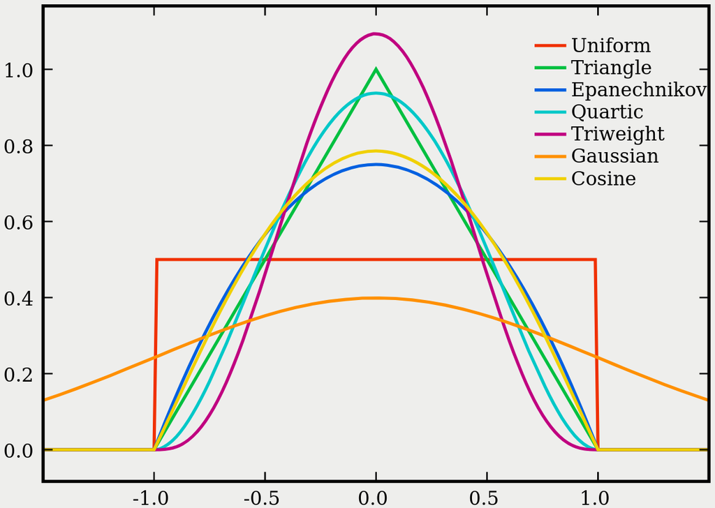

  https://en.wikipedia.org/wiki/Kernel_%28statistics%29#/media/File:Kernels.svg

  Some of the more widely applied kernels include:
  - Rectangular/uniform: all observations within the support of the kernel receive the same degree of similarity, corresponding to unweighted $k$-NN.
  - Triangle: weight is a linear function of distance within the kernel support.
  - Epanechnikov: weight is a quadratic function of distance within the kernel support.
  - Gaussian: weight is a quadratic function of distance. The Gaussian kernel has infinite support, meaning that each pair of observations, no matter how far apart, receives a positive degree of similarity.

  Kernels have a number of canonical properties and play an important role in statistics (most distance-based operations, such as smoothing, can be expressed using kernels).
- `scale` (logical): defines whether variables should be normalized to equal standard deviation. This is often reasonable to avoid implicit importance weighting through different natural scales (for example, recall that neighborhoods in a bivariate feature space are circular for quadratic distance – scaling either dimension will change which observations end up in the neighborhood).

In `mlr3` (using the `mlr3tuning` library), define an appropriate search space to tune over. We want to explore a range between 1 and 100 for $k$ and the kernel to be chosen from “rectangular”, “epanechnikov”, “gaussian”, “optimal”.

**Solution**

Each learner has a slot `param_set` containing all hyperparameters that can be set during tuning. The key function to define the search space is `ps` (short for parameter space). Furthermore, we need to instantiate every (hyper)parameter with an appropriate type - e.g., characterizing $k$ as integer ensures that only valid neighborhood sizes are queried. `scale` is logical (i.e., binary) and `kernel` is encoded as a factor with levels defining the choices to tune over:

```r
library(mlr3tuning)

search_space <- ps(
  k = p_int(1, 100),
  scale = p_lgl(),
  kernel = p_fct(c("rectangular", "epanechnikov", "gaussian", "optimal"))
)
```

Perform the tuning procedure using `TuningInstanceSingleCrit`. Set aside 200 test observations first. Use 5-fold cross validation and random search, and terminate the process after either 30 seconds or 200 evaluations.

**Solution**

We implement the HPO as follows:

```r
library(mlr3)
library(mlr3learners)
library(mlr3tuning)

# define task and learner
task <- tsk("german_credit")
set.seed(123)
train_rows <- sample(seq_len(task$nrow), 800, replace = FALSE)
test_rows <- setdiff(seq_len(task$nrow), train_rows)
task_train <- task$clone()$filter(train_rows)
task_test <- task$clone()$filter(test_rows)
lrn_knn <- lrn("classif.kknn")

# define resampling strategy
resampling <- rsmp("cv", folds = 5)

# create combined terminator object (either criterion, whichever is met first,
# can invoke the termination)
terminator_evals <- trm("evals", n_evals = 200)
terminator_runtime <- trm("run_time", secs = 30)
terminator <- trm(
  "combo",
  list(terminator_evals, terminator_runtime), any = TRUE
)

# create tuning instance from the above components
instance <- TuningInstanceSingleCrit$new(
  task = task_train,
  learner = lrn_knn,
  resampling = resampling,
  terminator = terminator,
  search_space = search_space
)

# create random-search optimizer (with parallel computing of batches, useful
# if we have multiple resources available)
optimizer <- tnr("random_search", batch_size = 20)
```

Then, press play:

```r
set.seed(123)
optimizer$optimize(instance)
```

You realize that a high AUC is the performance measure you are actually interested in. Modify the HPO procedure such that performance is optimized w.r.t. AUC.

**Solution**

Plug in custom performance metric (AUC needs the learner to output probabilities):

```r
lrn_knn <- lrn("classif.kknn", predict_type = "prob")
instance_auc <- TuningInstanceSingleCrit$new(
  task = task_train,
  learner = lrn_knn,
  resampling = resampling,
  terminator = terminator,
  search_space = search_space,
  measure = msr("classif.auc")
)
set.seed(123)
optimizer$optimize(instance_auc)
```

Visualize the tuning result with a suitable command. What do you observe regarding the impact of different hyperparameters on predictive performance? What are limits of such a form of analysis?

**Solution**

We can make convenient use of the autoplot functions in `mlr3`:

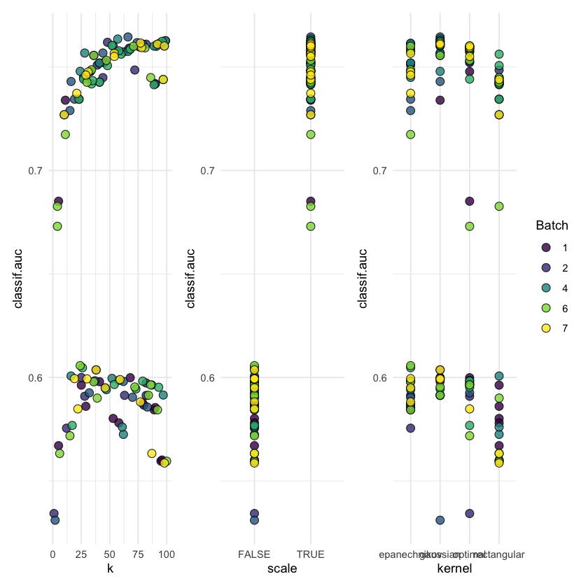

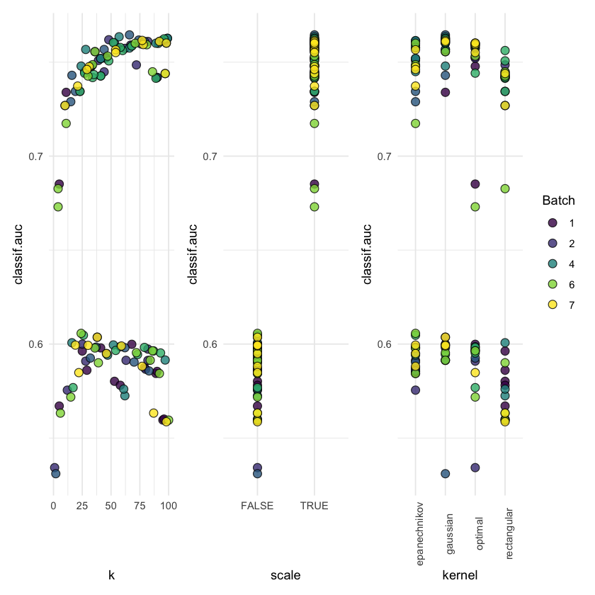

```r
library(mlr3viz)
library(ggplot2)
print(autoplot(instance_auc)) +
  theme(axis.text.x = element_text(angle = 90))
```

Increasing $k$ initially leads to an improvement that plateaus after around 50 neighbors. Scaling the variables also boosts performance. The choice of the kernel, on the other hand, does not seem to have much impact.

Obviously, the interpretability of these plots is limited: we only see *marginal* effects of individual hyperparameters. The fact that they really interact with each other contributes substantially to the difficulty of the tuning problem. We can clearly see this in the plot for $k$, where we have two quite distinct patterns corresponding to different values of `scale`.

After analyzing the tuning results, you notice that changes in $k$ are more influential for smaller neighborhoods. Re-run the HPO procedure with a log-transformation for $k$.

**Solution**

Tuning $k$ on log-scale requires a modification of the search space. For this, we need to transform the boundaries of the search interval and undo the transformation afterwards via `exp` (plus a rounding operation to ensure $k$ remains an integer number):

```r
search_space = ps(
  "k" = p_dbl(log(1), log(100)),
  scale = p_lgl(),
  kernel = p_fct(c("rectangular", "epanechnikov", "gaussian", "optimal")),
  .extra_trafo = function(x, param_set) {
    x$k = round(exp(x$k))
    return(x)
  }
)
instance_auc <- TuningInstanceSingleCrit$new(
  task = task_train,
  learner = lrn_knn,
  resampling = resampling,
  terminator = terminator,
  search_space = search_space,
  measure = msr("classif.auc")
)

set.seed(123)
optimizer$optimize(instance_auc)
```

With the hyperparameter configuration found via HPO, fit the model on all training observations and compute the AUC on your test data.

**Solution**

Performance on test data:

```r
optimal_config <- instance_auc$result_learner_param_vals
lrn_knn$param_set$values <- optimal_config
lrn_knn$train(task_train)
prediction <- lrn_knn$predict(task_test)
prediction$score(msr("classif.auc"))
```

**classif.auc:** 0.779010989010989

**Python Exercise**

The `KNeighborsClassifier` implementation used by `sklearn` contains several hyperparameters, three of which are to be tuned for our prediction:

- `n_neighbors`
- `weigths`
- `metric`

Describe briefly the role of each hyperparameter in the learning algorithm – which effects can be expected by altering them?

Furthermore, read the credit_for_py.csv, separate 138 test observations and perform necessary preprocessing steps.

**Hint**

Apply a `StandardScaler` on your feature space. What effect does scaling have on your $k$-NN-model?

**Solution**

Role of hyperparameters:

- `n_neighbors`: determines the size of the neighborhood and thus influences the locality of the model. Smaller neighborhoods reflect the belief that only very similar (close) neighbors should be allowed to weigh into the prediction of a new observation, and predictions may change strongly for only small changes of the input variables. If `n_neighbors` is chosen too small, we may encounter overfitting. Conversely, larger neighborhoods produce a more global model with larger parts of the input space receiving the same prediction. Setting `n_neighbors` too large may result in underfitting.
- `weights`: It determines the importance weights in the k-neighborhood. Possible values are:
  - ‘uniform’ : uniform weights. All points in each neighborhood are weighted equally.
  - ‘distance’ : weight points by the inverse of their distance. in this case, closer neighbors of a query point will have a greater influence than neighbors which are further away. This setting is strongly dependent on the parameter `metric`
  - [`callable`] : a user-defined function which accepts an array of distances, and returns an array of the same shape containing the weights.
- `metric`: Metric to use for distance computation. Some of the more widely applied metric include:
  - `euclidean`: distance is computed by the L2-norm
  - `manhattan`: distance is computed by the L1-norm
  - `cosine`: distance is computed by $1-\frac{u \cdot v}{\|u\|_2 \|v\|_2}$
  - `minkowski`: given the parameter p the distance is computed by $\|u - v\|_p$

Load the data credit_for_py.csv and seperate into train and test set:

```python
german_credit = pd.read_csv("https://raw.githubusercontent.com/slds-lmu/lecture_i2ml/master/exercises/data/credit_for_py.csv")
german_X = german_credit.copy()
german_y = german_X.pop("credit_risk")

# The full data set has 690 observations --> split at test_size = 0.2 to obtain 138 observations for testing.
X_train_unscaled, X_test_unscaled, y_train, y_test = train_test_split(german_X, german_y, test_size = 0.2, random_state=42)

# For kNN you have to scale your feature space such that the standard deviation is equal over all features.
# If we wouldn't do this, the result would be heavily weighted by larger scaled features.
scaler = StandardScaler()
# Fit and normalize the data after splitting it into training and test sets.
# This is to prevent ‘data leakage’ as the normalization would give the model additional information about the test set.
X_train = scaler.fit_transform(X_train_unscaled)
X_test = scaler.transform(X_test_unscaled)
```

Define an appropriate search space to tune over. We want to explore a range between 1 and 100 for `n_neighbors` and the distance calculation to be chosen from `uniform`, `manhattan`, `euclidean`, `cosine`.

**Solution**

Each instance of RandomizedSearchCV has a slot *param_distributions* containing all hyperparameters that can be set during tuning. It has to be passed as a dictionary or a list of dictionaries. Note that single values also have to be passed as a list to the dictionary.

Furthermore, we need to consider valid (hyper)parameter tuples in the design of the hyperparameter space.

Due to the **duck typing** behaviour of Python, we do not need to specify the type of our hyperparameters (type or the class of an object is less important than the methods it defines):

```python
# List hyperparameters that we want to consider for tuning.
n_neighbors = list(range(1,101))
weights = ['uniform', 'distance']
metric = ['euclidean', 'manhattan', 'cosine']
# Convert to dictionary and consider valid hyperparameter tuples
hyperparameters = [dict(n_neighbors=n_neighbors, weights=[weights[0]]),
                   dict(n_neighbors=n_neighbors, weights=[weights[1]], metric=metric)]
```

Perform the tuning procedure using `RandomizedSearchCV`. Use 5-fold cross validation, and terminate the process after 200 iterations. Also, utilize parallelization to fasten the computation.

**Solution**

We implement the HPO as follows:

```python
# Create new KNN instance
knn = KNeighborsClassifier()
# Use RandomSearch
clf = RandomizedSearchCV(
    estimator = knn, # fit a KNeighborsClassifier
    param_distributions = hyperparameters, # use defined parameter dictionary
    n_iter = 200, # sample 200 tuples out of 400 possible ones and iterate over these
    cv = 5, # use 5-fold CV
    n_jobs = -1, # use all processers available to speed up computing
    random_state = 123) # make your results reproducable
# Fit the model, i.e., carry out tuning and in the end, fit model with best hyperparameters
best_model = clf.fit(X_train,y_train)
# Print The value of best hyperparameters
print('Best n_neighbors:', best_model.best_estimator_.get_params()['n_neighbors'])
print('Best weights:', best_model.best_estimator_.get_params()['weights'])
print('Best metric:', best_model.best_estimator_.get_params()['metric'])
print('Accuracy:', best_model.score(X_test,y_test))
```

```
Best n_neighbors: 12
Best weights: distance
Best metric: manhattan
Accuracy: 0.782608695652174
```

You realize that a high AUC is the performance measure you are actually interested in. Modify the HPO procedure such that performance is optimized w.r.t. AUC.

**Solution**

```python
# Create new KNN instance
knn = KNeighborsClassifier()
# Use RandomSearch
clf_auc = RandomizedSearchCV(
    estimator = knn,
    param_distributions = hyperparameters,
    scoring = 'roc_auc', # use the AUC metric for finding the best hyperparameter set
    n_iter = 200,
    cv = 5,
    n_jobs = -1,
    random_state = 123)
# Fit the model
best_model_auc = clf_auc.fit(X_train,y_train)
# Print The value of best Hyperparameters
print('Best n_neighbors:', best_model_auc.best_estimator_.get_params()['n_neighbors'])
print('Best weights:', best_model_auc.best_estimator_.get_params()['weights'])
print('Best metric:', best_model_auc.best_estimator_.get_params()['metric'])
print('Accuracy:', best_model_auc.score(X_test,y_test))
```

```
Best n_neighbors: 37
Best weights: distance
Best metric: manhattan
Accuracy: 0.8754201680672269
```

You are interested in possible under- and overfitting of your hyperparameter setting. Use `validation_curve` from `sklearn.model_selection` to retrieve the training scores and cross-validation scores for a 5-fold-CV, depending on the AUC metric.

Visualize the tuning result with a suitable command. You may use the function provided below or a self-defined function.

Re-run the evaluation with unscaled features.

What do you observe regarding the impact of different hyperparameters and scaling on predictive performance?

What are limits of such a form of analysis?

**Function for plotting a validation curve**

```python
def plot_validation(train_scores, test_scores, param, param_range):
    """
    Plot the validation curve for a given hyperparameter.
    Parameters:
    ----------
    train_scores : array-like of shape (n_param_values, n_folds)
    Training scores for each hyperparameter value and fold.
    test_scores : array-like of shape (n_param_values, n_folds)
    Test scores (e.g., cross-validation scores) for each hyperparameter value and fold.
    param : str
    Name of the hyperparameter being varied.
    param_range : array-like of shape (n_param_values,)
    Range of values for the hyperparameter.
    Returns:
    -------
    None
    The function plots the validation curve.
    """
    train_scores_mean = np.mean(train_scores, axis=1)
    train_scores_std = np.std(train_scores, axis=1)
    test_scores_mean = np.mean(test_scores, axis=1)
    test_scores_std = np.std(test_scores, axis=1)

    plt.title("Validation Curve with KNN")
    plt.xlabel(param)
    plt.ylabel("Score")
    plt.ylim(0.0, 1.1)
    lw = 2
    plt.plot(
        param_range, train_scores_mean, label="Training score", color="darkorange", lw=lw
    )
    plt.fill_between(
        param_range,
        train_scores_mean - train_scores_std,
        train_scores_mean + train_scores_std,
        alpha=0.2,
        color="darkorange",
        lw=lw,
    )
    plt.plot(
        param_range, test_scores_mean, label="Cross-validation score", color="navy", lw=lw
    )
    plt.fill_between(
        param_range,
        test_scores_mean - test_scores_std,
        test_scores_mean + test_scores_std,
        alpha=0.2,
        color="navy",
        lw=lw,
    )
    plt.legend(loc="best")
    plt.show()
```

**Solution**

Plot for scaled training data:

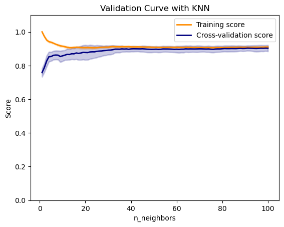

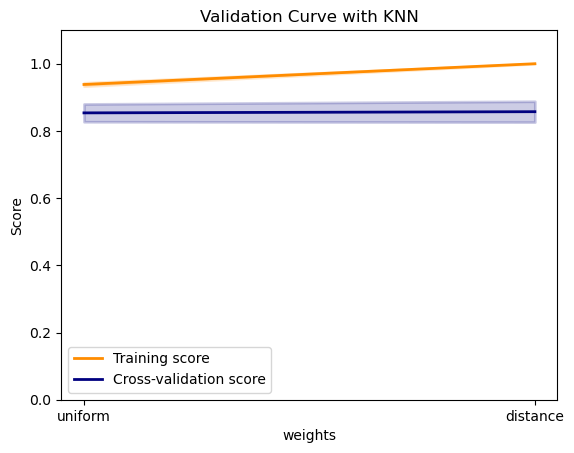

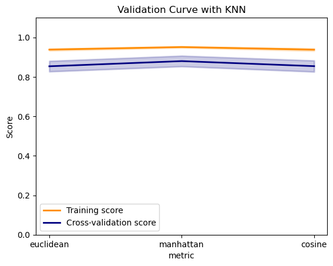

```python
hyper_full_set = dict(n_neighbors=n_neighbors, weights=weights, metric=metric)
plots = hyper_full_set.keys()

for plot in plots:
    train_scores, test_scores = validation_curve(
        KNeighborsClassifier(),
        X_train,
        y_train,
        param_name=plot,
        param_range=hyper_full_set[plot],
        cv = 5,
        scoring="roc_auc",
        n_jobs=-1,
    )
    plot_validation(train_scores, test_scores, plot, hyper_full_set[plot])
```

Plot for unscaled training data:

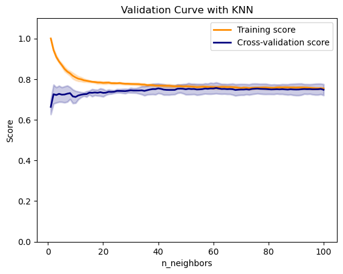

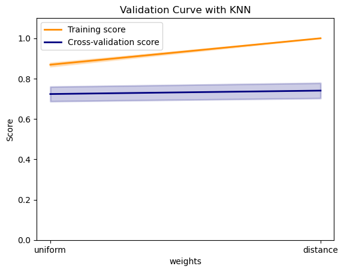

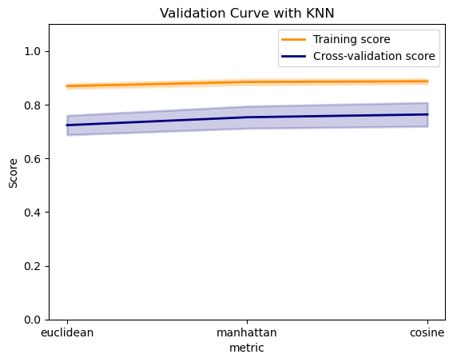

```python
for plot in plots:
    train_scores, test_scores = validation_curve(
        KNeighborsClassifier(),
        X_train_unscaled,
        y_train,
        param_name=plot,
        param_range=hyper_full_set[plot],
        cv = 5,
        scoring="roc_auc",
        n_jobs=-1,
    )
    plot_validation(train_scores, test_scores, plot, hyper_full_set[plot])
```

Increasing `n_neighbors` initially leads to an improvement that plateaus after around 50 neighbors. Scaling the variables also boosts performance. The choice of the metric, on the other hand, does not seem to have much impact. Note that the default metric compared with the uniform distribution is the euclidian one.

After analyzing the tuning results, you notice that changes in `n_neighbors` are more influential for smaller neighborhoods. Re-run the HPO procedure with a log-transformation for `n_neighbors` parameter list.

**Solution**

```python
# List hyperparameters that we want to tune, but with log-scaled n_neighbors
n_neighbors = list(np.linspace(np.log(1), np.log(100), 100))
n_neighbors = list(map(math.exp, n_neighbors))
n_neighbors = list(map(round, n_neighbors)) # now smaller numbers are much more likely to be chosen by RandomizedSearchCV

weights = ['uniform', 'distance']
metric = ['euclidean', 'manhattan', 'cosine']
# Convert to dictionary
hyperparameters = [dict(n_neighbors=n_neighbors, weights=[weights[0]]),
                   dict(n_neighbors=n_neighbors, weights=[weights[1]], metric=metric)]
```

```python
# Create new KNN instance
knn = KNeighborsClassifier()
# Use RandomSearch
clf_auc = RandomizedSearchCV(
    estimator = knn,
    param_distributions = hyperparameters,
    scoring = 'roc_auc', # use the AUC metric for finding the best hyperparameter set
    n_iter = 200,
    cv = 5,
    n_jobs = -1,
    random_state = 123)
```

With the hyperparameter configuration found via HPO, fit the model on all training observations and compute the AUC on your test data. Could you see any effect of the log-transformation for `n_neighbors`?

**Solution**

Performance on test data:

```python
# Fit the model
best_model_auc = clf_auc.fit(X_train,y_train)
# Print The value of best Hyperparameters
print('Best n_neighbors:', best_model_auc.best_estimator_.get_params()['n_neighbors'])
print('Best weights:', best_model_auc.best_estimator_.get_params()['weights'])
print('Best metric:', best_model_auc.best_estimator_.get_params()['metric'])
```

```
Best n_neighbors: 39
Best weights: distance
Best metric: manhattan
```

As can be observed, the log-transformation does not have a high effect on the tuning process.

```python
y_pred = best_model_auc.predict(X_test)
auc_score = roc_auc_score(y_test, y_pred)

print('AUC score:', auc_score)
print('Accuracy:', best_model_auc.score(X_test,y_test))
```

```
AUC score: 0.834873949579832
Accuracy: 0.8760504201680672
```